# Understanding and Forecasting the Community Impacts of Structure Fire

Kendra Hills, Myron Bañez, & Ben Keel

MUSA Practicum Feb 2023

## **Introduction**

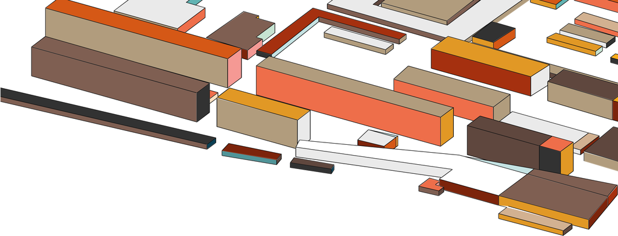

### Abstract

This projects explores the experiences of properties and neighborhoods after fires occur with the purpose of developing a predictive model that can inform the Philadelphia Fire Department (PFD) on the likelihood of redevelopment or vacancies for fire impacted structures. This intelligence will allow PFD and partner agencies to understand when pro-active expertise and services might have their highest impact. We want to thank Commissioner Adam Theil, Kathy Matheson, Andrew Newell the PFD, and our instructors Matt Harris and Michael Fichman for their guidance and support for this project.

### Motivation & Use Case

In 2022, there were 1.2 million structure fires in the country that led to 2,500 deaths — 276 of them children. Last year major cities like Philadelphia and New York grappled with severe and deadly structure fires. In Philadelphia specifically,41 people died from fires, while nearly 200 were injured,and thousands were displaced.

As it stands, the PFD has very limited knowledge about what happens after their job is complete, and there is no programmed set of economic development interventions that are used by public agencies in Philadelphia as a response to fire. The PFD expressed their desire to better understand and predict consequences of a fire so that they can better understand recovery patterns.

## The Data: Understanding Fire Incidents

With the help of the PFD, we were given access to proprietary data that consist of rich and extensive fire data collected by the department dating back to 2009.

To better understand the outcomes of fire impacted fires,we first conducted prelminatry literature review research on why fires occur in the first place. The following model, originally developed by Charles Jennings(1996),is a conceptualized model that represents the interrelationships between environmental, structural, and human factors as they relate to fire. We find this model useful as a way to devlop more powerful predictors of the incidence of fire and nuanced model to determine thier social and economic impacts in the future.

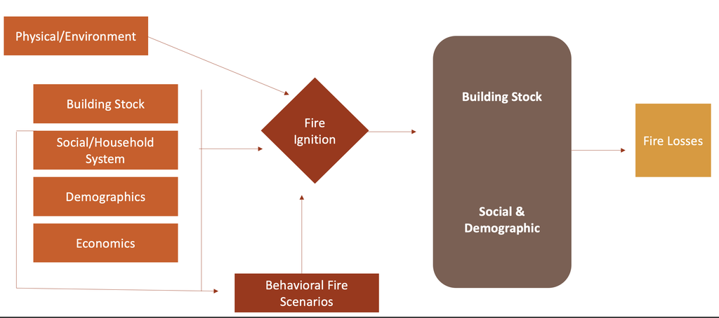

Jennings, 1996

### How Many Fires Occur Per Address?

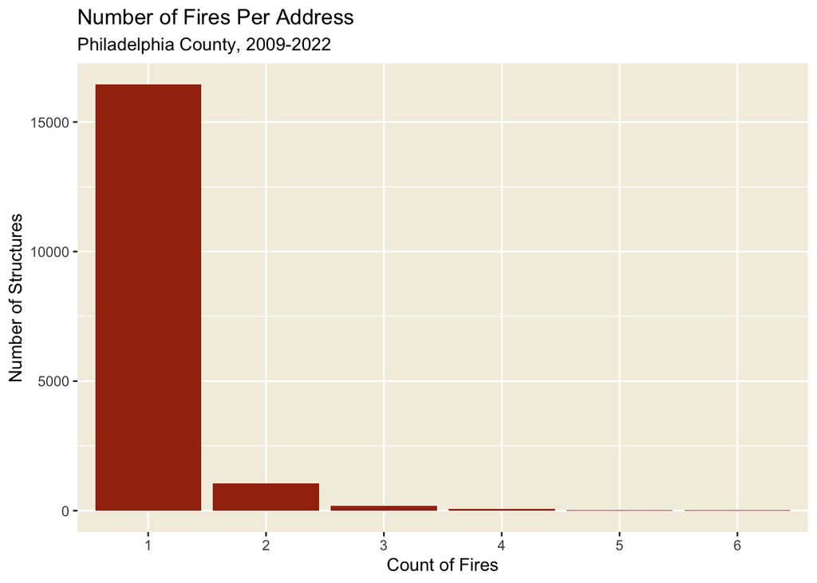

There have been at least one incident of a fire for over 15,000 structures in Philadelphia.

### Counts Over Time

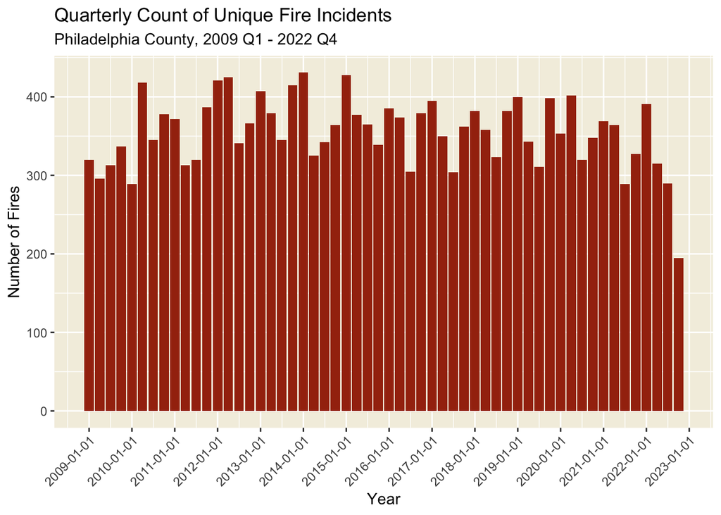

There is little unique patterns to the data, and it appears that fires have been relatively consistent over the last 15 years. - fires dip from July to September

### Property Use

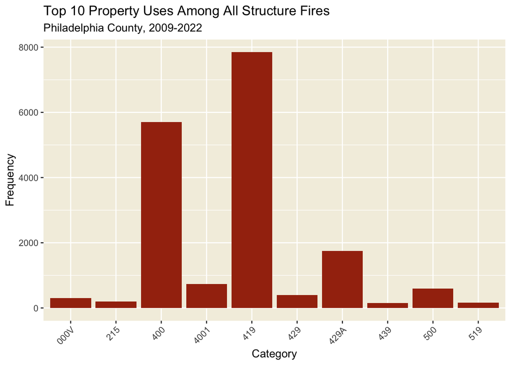

If we cut out non-residential buildings, which have very different types of fires and post-fire outcomes than residential buildings (supercategory 4), we still keep the vast majority of the data.

| Variable | Property Use Supercategory | Share (%) |
| --- | --- | --- |
| Property_Use_SuperCat | 4 | 84.57 |
| Property_Use_SuperCat | 5 | 6.17 |
| Property_Use_SuperCat | 2 | 2.18 |
| Property_Use_SuperCat | 1 | 1.87 |
| Property_Use_SuperCat | 0 | 1.59 |
| Property_Use_SuperCat | 8 | 1.36 |
| Property_Use_SuperCat | 3 | 1.08 |
| Property_Use_SuperCat | 7 | 0.57 |
| Property_Use_SuperCat | 9 | 0.39 |
| Property_Use_SuperCat | 6 | 0.17 |
| Property_Use_SuperCat | U | 0.05 |
| Property_Use_SuperCat | N | 0.01 |

### Measures of Fire Severity

When measuring outcomes of buildings that experience a fire, the obvious question is how severe the fire was. There are multiple possible determinants in the data. We ended up using the first one, the ordinal variable labeled “fire spread”. Here’s how we made our decision:

- disruption of fire spread within he fire spread severity. SO using fire spread is ideal

-Incident type: weighted to one cateogry, not as useful

-no record for a lot of fire incidents

#### Fire Spread

In our research, time had a big correlation with damage. The longer fire burns close to metal and concrete, the hotter those critical infrastructure pieces get, and the less able they are to hold weight.

Source: https://www.homego.com/blog/house-fire-damage/

This was the simplest and most normally-distributed feature as compared to the three others we considered.

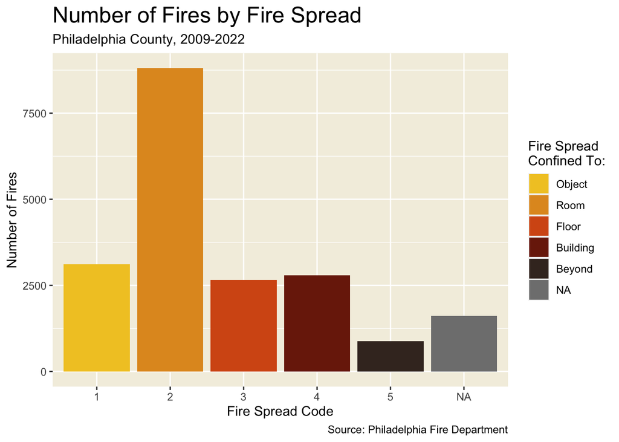

#### Floor Damage Counts

Originally these counts seemed useful as direct measures of damage, but the large amount of “no record” instances means that it can’t function as a reliable metric.

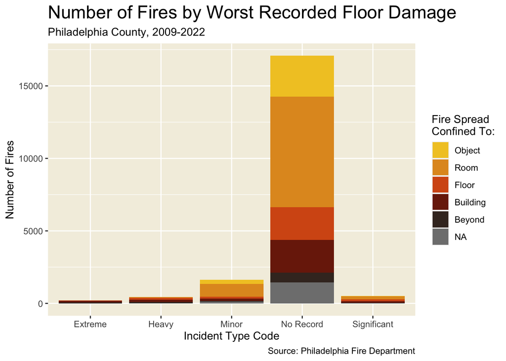

#### Cad Nature Code Description

We have more specific categories, like CAD nature code description.

#### Incident Type

Incident type measures whether the interior or exterior of the structure has collapsed. Considering outcomes like demolition, vacancy, and major construction for homes affected by a fire, then collapse seems like a strong candidate for collelation.

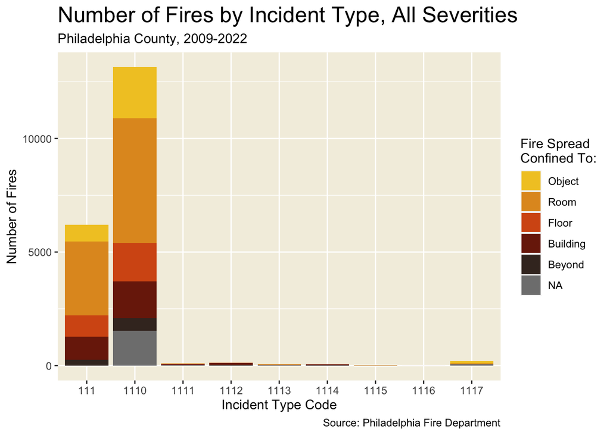

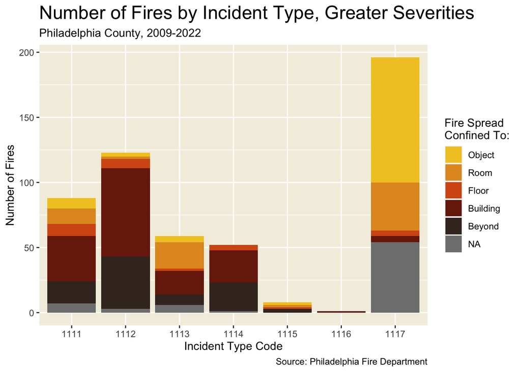

As a result, we picked fire spread as our measure of severity.

### Outliers

We will classify an outlier as an observation more than 3 standard deviations away from the population mean.

The mean number of fires per location is 1.115, weighted by the large amount of places where only 1 fire has occurred. The standard deviation of this fire population is 0.521. The result, 2.678, means any of the 293 locations with three or more fires will be classified as an outlier.

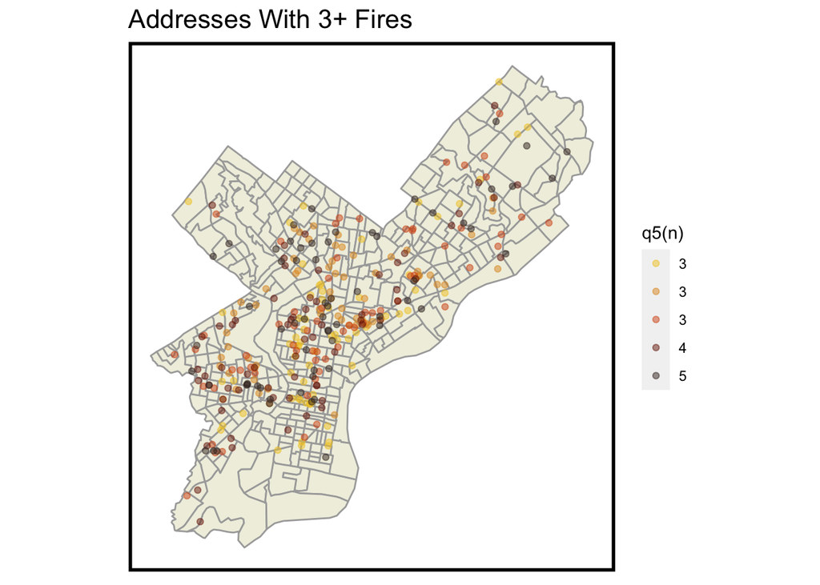

Apart from centers of population, there is not an obvious geographic distribution of the outliers. More research could be useful with ACS data to determine correlations.

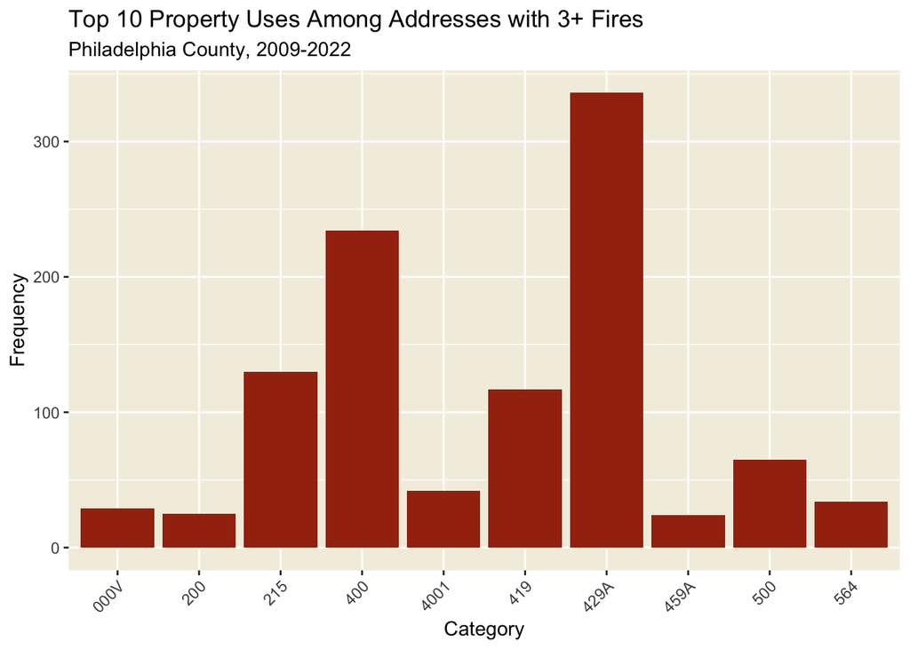

There is a difference among property use, in that 215, the designation for “schools, high/junior/middle” is now in the top 3. Code 500, the designation for “mercantile, business, other”, also has a greater share than in the complete data set.

Regardless of the cause, these school and commercial fires are very different in their causes and outcomes than a residential fire. This outlier analysis supports our decision to remove the non-residential fires from our research in order to focus what narratives we can observe.

## **Data Wrangling**: Panal Data Analysis

A key element to the exploratory analysis is understanding how fires relate to properties and other relevant data that will help us better predict post fire impacted properties. To start, we have decided to work with 311 complaints, permit data, and property assessment data to further explore and craft differnt post fire scenarios.

### Fire Panel - Initial, Count, and Final Panel

The fire panel is created as the base template containing the key information related to fire incidents. The dataset first undergoes numerous operations to refine the information.

The current structure of the initial dataset contains information regarding fire incidents from January 2009 - December 2022. Despite having the same address, there will be a new record of fire incident for that address as each fire has a unique incident number. In order to see the count and severity of properties with and without a fire incident we create a panel to display the observations of every possible address and time combination.

```r
# Initial panel
dat.panel <-
  expand.grid(quarter = unique(dat$quarter),
              address = unique(dat$address))
```

```r
# Count Panel
count.panel <-
  dat %>%
  st_drop_geometry() %>%
  group_by(quarter, address, fire_spread) %>%
  count(address, sort=TRUE)

# Changing address to factor for join purposes later
count.panel$address <-
  as.factor(count.panel$address)
```

```r
# Final Panel
final.panel <- left_join(dat.panel, count.panel, by=c("address", "quarter")) # Join
final.panel <- final.panel %>% dplyr::select(address, quarter, fire_spread, n) %>% rename(count = n) # Condensing & renaming
final.panel[is.na(final.panel)] <- 0 # Assigning 0 to NA for everything
final.panel$fire_spread <- as.numeric(final.panel$fire_spread) # Making fire_spread numeric

# Calculating the maximum severity score
final.panel <-
  final.panel %>%
  group_by(address, quarter, count) %>% summarise(severity_index = max(fire_spread))

g(final.panel)
```

```
## Rows: 998,603
## Columns: 4
## Groups: address, quarter [998,592]
## $ address        <fct> 1240 GILHAM ST, 1240 GILHAM ST, 1240 GILHAM ST, 1240 GI…
## $ quarter        <dttm> 2009-01-01, 2009-04-01, 2009-07-01, 2009-10-01, 2010-0…
## $ count          <dbl> 0, 0, 0, 0, 1, 0, 0, 0, 0, 0, 0, 0, 0, 0, 0, 0, 0, 0, 0…
## $ severity_index <dbl> 0, 0, 0, 0, 3, 0, 0, 0, 0, 0, 0, 0, 0, 0, 0, 0, 0, 0, 0…
```

```r
#Data from https://www.opendataphilly.org/dataset/opa-property-assessments

#metadata at: https://metadata.phila.gov/#home/datasetdetails/5543865f20583086178c4ee5/representationdetails/55d624fdad35c7e854cb21a4/?view_287_page=3

# Reading the data
AllOPA <- read_csv("/Users/kendrae.hills/Desktop/Spring 2023/MUSA_Practicum/opa_properties_public-2.csv")

# Creating geometry for the properties
OPA_sf <- AllOPA%>%
  drop_na(lng, lat)%>%
  st_as_sf(coords = c("lng", "lat"),
           crs = "EPSG:4326")

g(OPA_sf)
```

```
## Rows: 582,020
## Columns: 79
## $ objectid                      <dbl> 267696686, 267696687, 267696688, 2676966…
## $ assessment_date               <dttm> 2021-07-16 18:15:31, 2021-07-16 18:15:3…
## $ basements                     <chr> NA, NA, NA, NA, NA, NA, "D", NA, NA, NA,…
## $ beginning_point               <chr> "480'4\" N DIAMOND", "273' N OF NORRIS S…
## $ book_and_page                 <chr> NA, NA, NA, NA, NA, NA, NA, NA, NA, NA, …
## $ building_code                 <chr> "SR", "SR", "U50", "RB", "PB0", "Y50", "…
## $ building_code_description     <chr> "VACANT LAND RESIDE < ACRE", "VACANT LAN…
## $ category_code                 <dbl> 6, 6, 2, 6, 4, 3, 2, 6, 6, 6, 1, 3, 6, 4…
## $ category_code_description     <chr> "VACANT LAND", "VACANT LAND", "MULTI FAM…
## $ census_tract                  <dbl> 151, 151, 147, 381, 382, 377, 136, 17, 1…
## $ central_air                   <chr> NA, NA, NA, NA, NA, NA, NA, NA, NA, NA, …
## $ cross_reference               <dbl> NA, NA, NA, NA, NA, NA, NA, NA, NA, NA, …
## $ date_exterior_condition       <dttm> NA, NA, NA, NA, NA, NA, NA, NA, NA, NA,…
```

[output cut: 66 more lines]

# OPA Panel

```r
# Reducing columns
opa_dat_small <- OPA_sf %>%
  dplyr::select(location, category_code, category_code_description, building_code, building_code_description, building_code_new, building_code_description_new, total_area, total_livable_area, owner_1, owner_2, market_value, market_value_date, number_of_bedrooms, number_of_bathrooms, number_stories, interior_condition, assessment_date, year_built, year_built_estimate, zoning, quality_grade)%>%
  rename(address = location)

# Filtering for residential properties
opa_dat_small <- opa_dat_small %>% filter(category_code == 1 | category_code == 2 | category_code == 3)

# Extracting just the addresses
opa_dat_small <- opa_dat_small%>%
  dplyr::select(address)%>%
  st_drop_geometry()
```

```r
# Time Panel
quarter <- c("Q1", "Q2", "Q3", "Q4") # Creating quarters
year <- c(2009, 2010, 2011, 2012, 2013, 2014, 2015, 2016, 2017, 2018, 2019, 2020, 2021, 2022) # Creating years

comb <- expand.grid(year = year, quarter = quarter)%>%
  mutate(yq = paste(year, ":", quarter))%>%
  mutate(yqDT = yq(yq))%>%
  arrange(yqDT)

time.panel <- as_tibble(comb)%>%
  dplyr::select(yqDT)
```

### Combined Panel

```r
# Combining OPA and Fire
opa_count.panel <- full_join(opa.panel, final.panel, by=c("address", "quarter")) # Join
opa_count.panel[is.na(opa_count.panel)] <- 0 # Assigning 0 to NA for everything - DO WE WANT THIS?

# Subset of data to observe for validity and minimize processing time
ogontz <-
  filter(opa_count.panel, address == "5600 OGONTZ AVE")

# Ogontz has 6 fires now instead of 9?
```